# Hate in Context

Week 2: Demographic Change and Hate Crime

Violeta Haas

Department of Political Science

School of Social Sciences and Philosophy

Trinity College Dublin

# This Week

1. Theoretical backdrop — contact & group threat
2. **Part I** — Hangartner et al. (2019)
3. **Part II** — Cikara et al. (2022)
4. **Part III** — Dancygier et al. (2022)
5. Putting the readings together

# Theoretical backdrop

## Group discussion (≈8 min)

In groups of 3–4:

1. **What is contact theory?** What does it predict when minority presence grows and under what conditions?
2. **What is group threat theory?** What does it predict and what kinds of “threat” might it include?

## Contact theory

When minority presence grows…

… contact **reduces prejudice**, if people meet under the right conditions (Allport, 1954):

- Equal status
- Common goals
- Cooperative environment (not pure competition)
- Institutional support (set of norms/regulations)

## Group threat theory

When minority presence grows…

… out-group presence raises perceived threat to the majority’s position, leading to **more prejudice** (Blalock, 1967).

Threat comes in two main forms:

### Realistic threat

Competition over **scarce resources**

→ Jobs, housing, welfare, public services

### Symbolic threat

Threat to **values, norms, identity**

→ Culture, religion, language

# Part I — Hangartner et al. (2019)

## Most or least likely case?

Hangartner et al. study Greek islands during the 2015–16 refugee crisis.

For each theory, is that setting a **most likely** or **least likely** case for the mechanism to be activated and why?

## Hangartner et al. (2019): the setting

What happened:

- Sudden, large refugee arrivals on islands close to Turkey
- Almost everyone left within about a day for Athens and beyond
- Little lasting settlemen + chaotic local management

**So, most or least likely?**

→ **Contact:** least likely (proximity ≠ contact, fleeting, not cooperative)

→ **Realistic/symbolic threat:** also weak (no lasting jobs, welfare, or identity competition)

## Identification strategy

[figure not shown]

**Selection problem:** Regions with more refugee arrivals often already differ:

*Self-selection*

- Refugees might choose places with jobs, co-ethnic networks, or a reputation for being welcoming

*Administrative selection*

- Authorities may send refugees to some municipalities and not others (e.g. available housing, reception capacity, or political considerations)

→ X and Y share many causes! Naive X–Y comparison mixes exposure with pre-existing differences. Confounding (**U**)!

## Identification strategy: the instrument

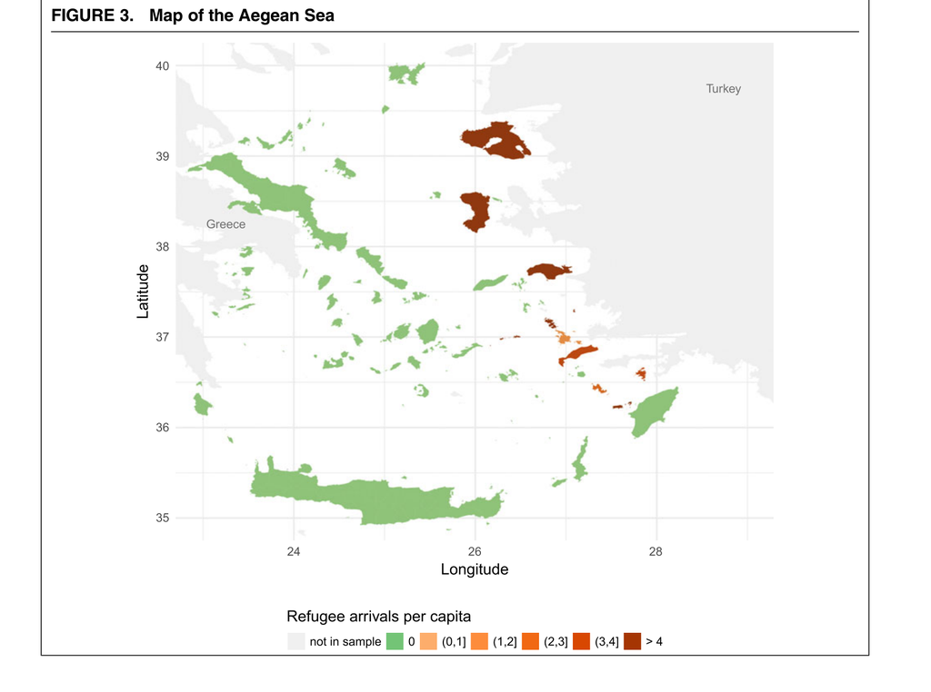

**Instrument Z:** distance to Turkey.

- Geography pushes boats to closer islands, not (self-)selection: welcomingness or admin readiness.
- **Two-stage least squares (2SLS):** (Z → Y) / (Z → X)
  - *First stage* (Z → X): how distance changes exposure
  - *Reduced form* (Z → Y): how distance changes hostility
- Must hold: distance only affects hostility *through* exposure.

→ *Exclusion restriction*: fails if being close to Turkey changes hostility for any reason other than more arrivals.

## 2 min. discussion with neighbour

Suggest an instrument **Z** (shifts X & affects Y only through X).

Valentim, A., Klüver, H., & Erfort, C. (2025). How nuclear power hurts the Greens: Evidence from German nuclear power plants. *Electoral Studies*, 96, 102959.

**Z:** seismic risk → plants are rarely sited in earthquake-prone areas

**Disclaimer**

IV solves confounding *in theory*; in practice the fights are about **weak Z**, who the effect is for (**LATE**), and whether **exclusion** is believable.

Additional resource: Scott Cunningham, [*Causal Inference: The Mixtape*](https://mixtape.scunning.com/) (IV chapters).

## Findings

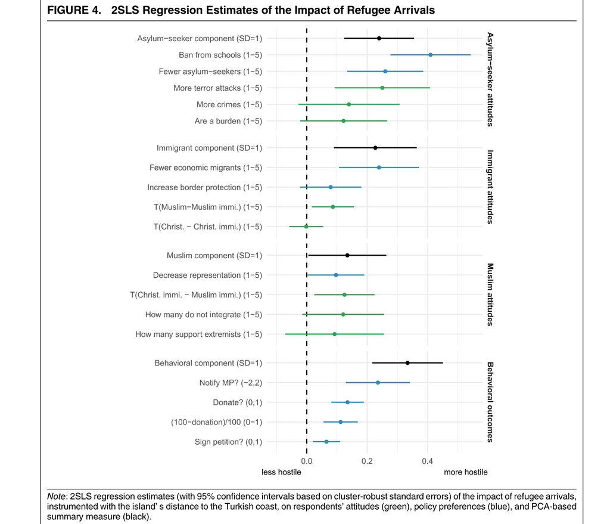

**Findings:** islands closer to Turkey (more exposure) show higher:

- exclusionary attitudes/hostility
- anti-asylum & anti-immigrant policy preferences
- behaviour (petition/donate against refugees)

**Puzzle:** contact and group threat were both weak here. Yet, hostility still rose. What’s left is **mere exposure**: even a brief, chaotic presence of arrivals (with little lasting settlement) can harden attitudes → **situational social threat**.

# Part II — Cikara et al. (2022)

## Ebbinghaus illusion

**Which hollow circle is bigger?** **Why might they look different even if they aren’t?**

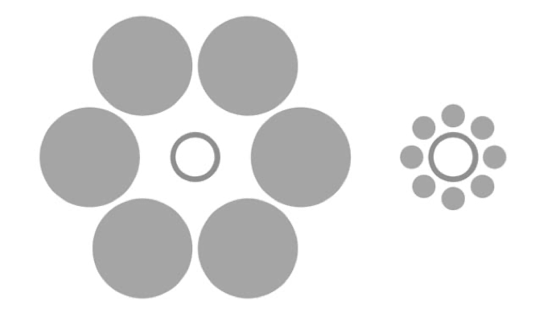

→ The size of the solid gray circles affects the *apparent* size of the hollow circles, even though they are the same size.

→ The same-sized group may be encoded very differently depending on the size of all other groups surrounding it.

## Group reference dependence

**RQ:** How does demographic change affect local intergroup dynamics?

**Argument:** *Group reference dependence hypothesis*

Violence and negative attitudes toward each minoritized group depend on the number and size of *other* minoritized groups in a community, i.e., their **relative ranks in size**.

## 2 min. discussion with neighbour

1. What role do stereotypes or essentialized properties (e.g., unchangeable group characteristics) play in this framework?

   → **None.** Something about group-size rank is unassociated with the threat-inducing characteristics of any particular minority group.
2. What psychological finding about how people judge group sizes do they build on to focus on ranks rather than absolute size?

   → People are mostly **inaccurate** about absolute size and proportions (**metric knowledge**), but quite **accurate** about relative sizes (**mapping knowledge**).

**Let’s try it out!**

## Part 1: Rank by size (≈3 min)

**Rank Dublin City’s largest immigrant groups by size** (largest → smallest).

[figure not shown]

1. Open Blackboard → Week 02 → POU44653 Week 2: Mapping Knowledge or Scan QR-code
2. Drag the ten citizenships into order
3. Do not consult others
4. Anonymous

## Part 2: Mapping vs. Metric Knowledge (≈5 min)

**Dublin City** had **580,237** residents in Census 2022. For each citizenship below, guess (1) how many people and (2) what share of the city that is.

| Citizenship | Absolute number | % of total population |
| --- | --- | --- |
| Italy |  |  |
| China |  |  |
| United States |  |  |
| Romania |  |  |
| Poland |  |  |
| France |  |  |
| Brazil |  |  |
| Spain |  |  |
| India |  |  |
| United Kingdom |  |  |

## Solution

[Let’s look at your ranking!](https://tcdpolls.vevox.com/#/meeting/955113/polls)

Dublin City, Census 2022 (580,237):

| Citizenship | Absolute number | % of total population |
| --- | --- | --- |
| Brazil | 11,186 | 1.93% |
| India | 10,318 | 1.78% |
| Romania | 10,049 | 1.73% |
| Poland | 7,233 | 1.25% |
| Italy | 6,945 | 1.20% |
| United Kingdom | 6,917 | 1.19% |
| Spain | 6,285 | 1.08% |
| France | 4,613 | 0.80% |
| China | 3,671 | 0.63% |
| United States | 3,560 | 0.61% |

CSO Census 2022 (F5001), usually resident population by citizenship, Dublin City Council.

## Finding 1

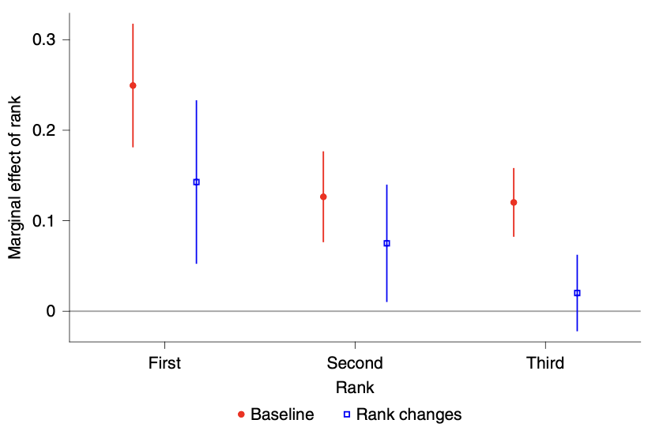

**Baseline (red):** being 1st / 2nd / 3rd in local size rank → more victimization than being 4th (strongest for 1st).

**Rank changes (blue):** same pattern when a group’s rank changes over time in the same county, i.e., comparing the same groups in the same places before vs after a rank switch.

→ Relative size rank predicts hate-crime victimization, even after accounting for group size and county/group fixed-effects (time-invariant characteristics).

## Why only violent hate crimes?

They also re-run the analysis **excluding non-violent hate crimes**.

**Why do that?**

→ Violent hate crimes are reported more reliably than non-violent ones, so the rank effect is less likely to be a measurement artifact.

## Finding 2

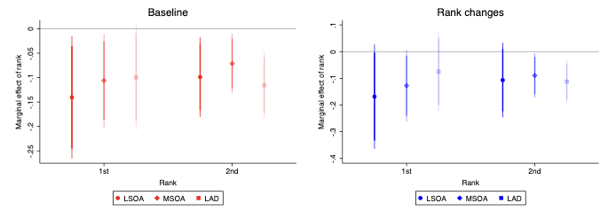

Geographic scales (small → large): LSOA → MSOA → LAD

**What does the plot show?** At which scale is the effect strongest, and what does that imply about *how* people learn ranks?

→ Rank is most likely encoded via **local experience** (effect stronger for smaller regional units).

## 2 min. discussion with neighbour

If people learn about ranks from everyday life, **what would they actually notice?**

→ Can you come up with an everyday example where group A now feels larger relative to group B than it used to?

## Example: a rank switch in the news

[figure not shown]

→ Census coverage of Hispanics surpassing Black Americans as the largest US minority.

## Example: public holidays as cues

[figure not shown]

→ NYC adds Diwali to the school calendar in recognition of the city’s growing South Asian and Indo-Caribbean communities.

## Example: 59 Brick Lane

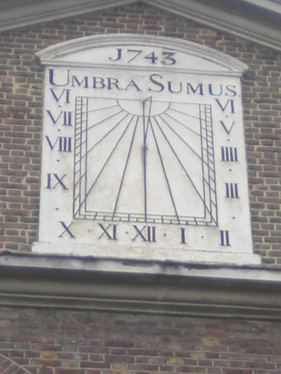

**Huguenot: *La Neuve Église***  
Sundial dated **1743**: *Umbra Sumus* (“we are but shadows”). Built by French Protestant silk weavers in Spitalfields.

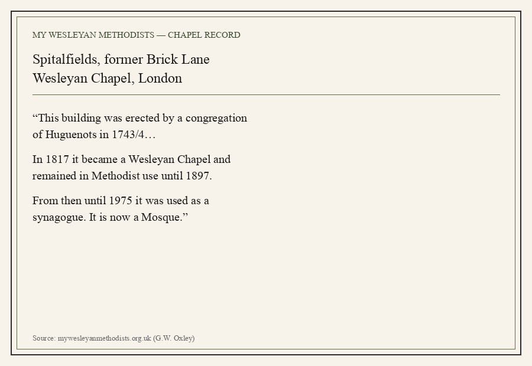

[figure not shown]

**Spitalfields Great Synagogue**  
Cutner (1930s): *Machzike Hadath*; synagogue from **1897**; Eastern European Jewish East End.

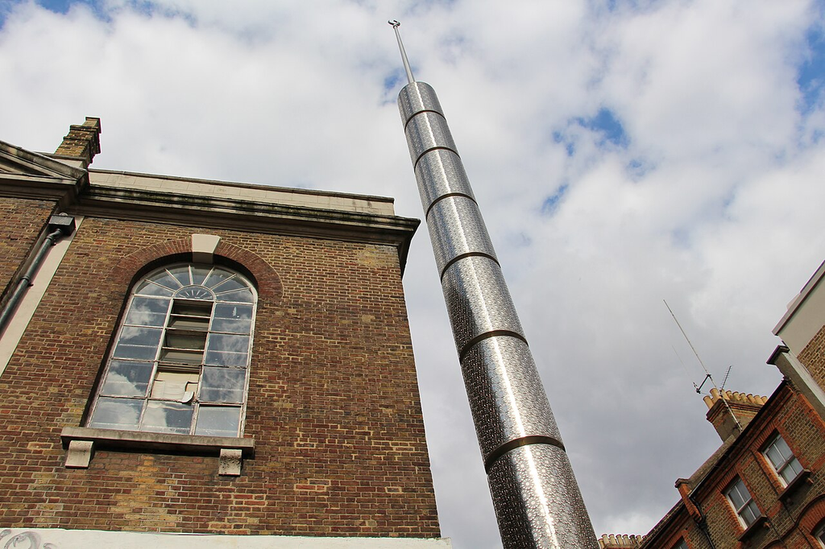

**Brick Lane Jamme Masjid**  
Mosque since **1976**, mainly the local Bangladeshi Muslim community.

→ One address, successive congregations: local institutions sometimes track relative group size over time.

## What kinds of cues?

- Face-to-face interactions
- Media attention to demographic change
- (Dis)appearance of (cultural) institutions (e.g., religious buildings, public holidays, LGBTQ+ venues)

## Finding 3

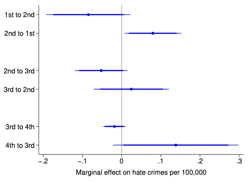

Supplementary Fig. F.6 from Cikara et al. (2022)

**Up vs down:** when a group moves up in local size rank (e.g. 2nd → 1st), hate-crime victimization rises. When it moves down (1st → 2nd), victimization falls.

→ **Rank effects are roughly symmetric**. Authors read this as **substitution** of prejudice across targets (fixed amount of discrimination redistributed among minority targets).

**But:** the same pattern can arise without substitution. Example: Group that dropped in rank might see fewer attacks because members move away (compositional change, not prejudice transferred).

# Part III: Dancygier et al. (2022)

## Who commits hate crime?

**Perpetrators are overwhelmingly male.**

- **Germany** (right-wing extremist hate crime): roughly **85–97% men** *(cited in Dancygier 2023)*
- **London** (hate-crime, 2014–16): **78% men** *(Walters & Krasodomski-Jones 2018)*

→ Hate crime perpetrators ≈ mostly men (often young / mid-life).

**Reminder: two families of explanation**

### Individual-level

Psychological traits & offender behaviour

Cognitive and affective processes that drive perpetrators to commit hate crime

### Contextual

Would-be perpetrators’ social environment

Political, cultural, sociological, and economic conditions that make bias-motivated violence more or less likely

→ Dancygier et al. (2022) integrate both, by looking at **profile-specific contextual** drivers.

## Mating competition

**Central concept:** *Mating competition*

- Function of the sex ratio (e.g., 1:1 → little competition)

**Assumptions**

- Local mating pools with disproportionate numbers of men make it harder for heterosexual men to find female partners
- Native heterosexual men perceive refugees as competitors on the “mating market”

## Finding 1

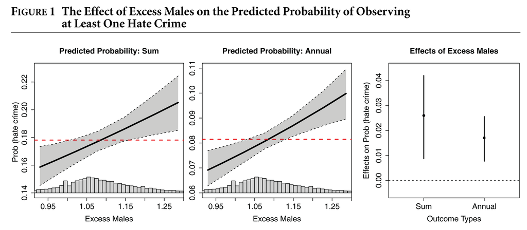

→ Areas where men significantly outnumber women (more excess males) have higher probabilities and levels of anti-refugee hate crime.

## From Macro to Micro

Finding 1 is **ecological (established on the macro-level only)**: male-heavy places → more anti-refugee hate crime.

[video not shown]

If the player fails, use: youtube.com/watch?v=5Vxbv138MuQ

## Why go to the micro level?

**1. Danger of ecological fallacy:** Areas with skewed sex-ratios experience more hate-crimes, therefore men in those places commit hate crime *because* they fear mate competition.

→ *place pattern ≠ individual mate-competition motive*: place pattern could omit important context.

**2. Theory implications for the individual-level**

1. Who should feel threatened?

→ Threatened: men in mating-active age.

2. Which refugees should be the target?

→ Targets: mainly male refugees as mating competitors.

**Macro-level analysis alone can’t settle either. A survey can!**

## Finding 2

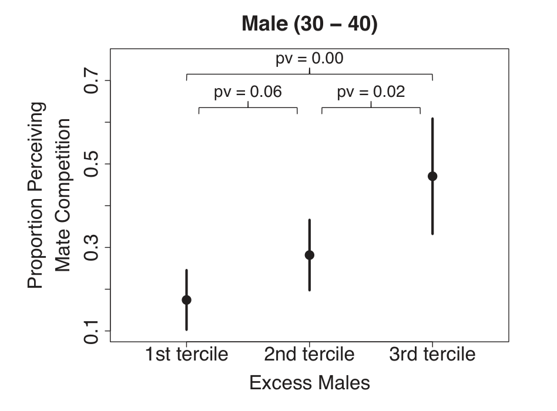

→ Perceptions of native–refugee mate competition rise in areas with excess males, especially among **men in the most mating-active age range**.

## What about (support for) hate crimes?

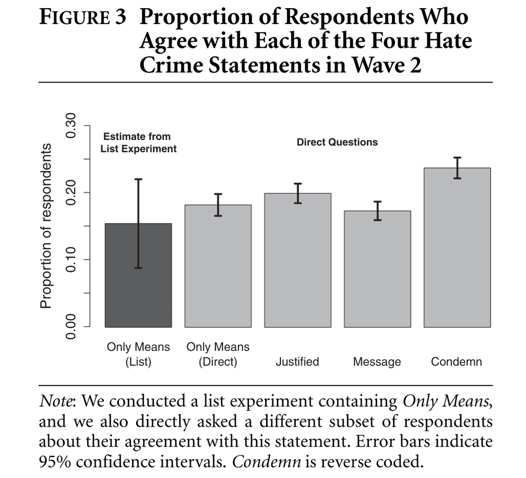

Figure 3 from Dancygier et al. (2022)

**Problem:** direct questions on hate-crime support invite **social desirability** bias (people hide unpopular views).

→ **List-experiment:** ask only *how many* list items you agree with.

- **Control:** 3 harmless items (e.g., “Taking a few minutes a day to relax matters in a hectic world”)
- **Treatment:** same 3 + sensitive item

→ Difference in means ≈ share endorsing the sensitive item.

**Finding:** people do not hide support. List estimate ≈ 15%; asked directly ≈ 18% (insignificant difference). If anything, direct answers are slightly higher.

## Finding 3

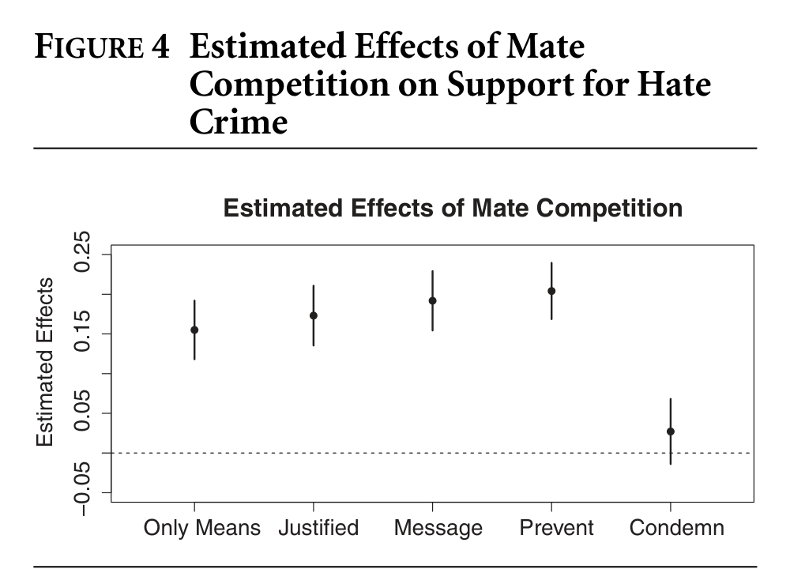

→ Concerns over mate competition are a robust predictor of hate-crime support, even with controls for other attitudes.

→ Effects are stronger for **goal-oriented** items (violence as a means to send a message / keep refugees out) than for a **value** item (whether politicians should condemn attacks more forcefully).

## Two unsettling implications

**1. Integration can raise hostility**

> “[M]ajority opposition against minorities rises when the latter are in fact integrating into majority settings and intergroup barriers begin to fall.”

> (Dancygier et al. 2022)

→ Refugees entering dating/marriage markets could be interpreted as a form of social integration but, Dancygier et al. (2022) show, this intensifies threat.

**2. While perpetrators are few… supportive attitudes are not**

→ A sizable share of survey respondents support violent acts against Refugees and do not feel the need to hide these attitudes.

→ Perpetrators may be the exception, but they can be empowered by broader attitudes favoring hate crime.

## Group discussion (≈5 min)

In groups of 3: pick one of the two cases below. What follows for mate competition and for hate crime?

**(A) Ukrainian refugee inflows**

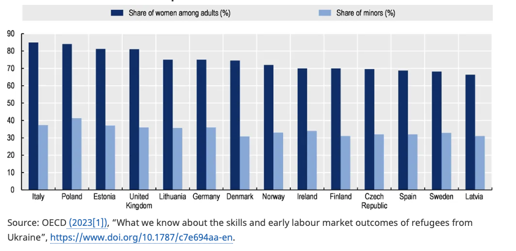

**(B) Rising LGBTQ ID among Gen Z women**

[figure not shown]

# Putting it together

# Outlook

## Next week: economic causes

**Week 3** (Mon 28 / Wed 30 Sep): economic causes and hate crime.

**Required readings**

- Riaz, S. (2023). Does inequality foster xenophobia? Evidence from the German refugee crisis. *Journal of Ethnic and Migration Studies*, 50(2), 359–378.
- Bestenbostel, A., & Peralta, A. (2026). WARNings: The impact of negative economic news on racial animus. *Journal of Economic Behavior & Organization*, 243, Article 107399.

Weekly comments due **Sunday 27 Sep, 11:59 pm**.

# Questions?

# Goodbye!

See you next week.